# fifa_data_G1S4_project 1_Python for DS

● Load and explore data

1. Import the required libraries and read the dataset.
2. Check the first few samples, shape, info of the data and try to familiarize

yourself with different features. 3. Drop the columns which you think redundant for the analysis.

[Hint: columns like 'Photo','Flag','Club Logo']

```python
#● Load and explore data
#------------------------
#1. Import the required libraries
import pandas as pd
import numpy as np
import matplotlib.pyplot as plt
import seaborn as sns
sns.set(style ="ticks")
import warnings
warnings.filterwarnings('ignore')
```

```python
#● Load and explore data
#-------------------------
#1. Read the datasets
#2. Check the first few samples.
fifa_Var_Info=pd.read_csv('fifa_ variable_information.csv')
Fifa_Df = pd.read_csv('fifa.csv')
#Fifa_Df.describe().head(5)
#fifa_Var_Info.describe().head(5)

Fifa_Df.head()
```

|  | ID | Name | Age | Photo | Nationality | Flag | Overall | Potential | Club | Club Logo | ... | Composure | Marking | StandingTackle | SlidingTackle | GKDiving | GKHandling | GKKicking | GKPositioning | GKReflexes | Release Clause |
| --- | --- | --- | --- | --- | --- | --- | --- | --- | --- | --- | --- | --- | --- | --- | --- | --- | --- | --- | --- | --- | --- |
| 0 | 158023 | L. Messi | 31 | https://cdn.sofifa.org/players/4/19/158023.png | Argentina | https://cdn.sofifa.org/flags/52.png | 94 | 94 | FC Barcelona | https://cdn.sofifa.org/teams/2/light/241.png | ... | 96.0 | 33.0 | 28.0 | 26.0 | 6.0 | 11.0 | 15.0 | 14.0 | 8.0 | €226.5M |
| 1 | 20801 | Cristiano Ronaldo | 33 | https://cdn.sofifa.org/players/4/19/20801.png | Portugal | https://cdn.sofifa.org/flags/38.png | 94 | 94 | Juventus | https://cdn.sofifa.org/teams/2/light/45.png | ... | 95.0 | 28.0 | 31.0 | 23.0 | 7.0 | 11.0 | 15.0 | 14.0 | 11.0 | €127.1M |
| 2 | 190871 | Neymar Jr | 26 | https://cdn.sofifa.org/players/4/19/190871.png | Brazil | https://cdn.sofifa.org/flags/54.png | 92 | 93 | Paris Saint-Germain | https://cdn.sofifa.org/teams/2/light/73.png | ... | 94.0 | 27.0 | 24.0 | 33.0 | 9.0 | 9.0 | 15.0 | 15.0 | 11.0 | €228.1M |
| 3 | 193080 | De Gea | 27 | https://cdn.sofifa.org/players/4/19/193080.png | Spain | https://cdn.sofifa.org/flags/45.png | 91 | 93 | Manchester United | https://cdn.sofifa.org/teams/2/light/11.png | ... | 68.0 | 15.0 | 21.0 | 13.0 | 90.0 | 85.0 | 87.0 | 88.0 | 94.0 | €138.6M |
| 4 | 192985 | K. De Bruyne | 27 | https://cdn.sofifa.org/players/4/19/192985.png | Belgium | https://cdn.sofifa.org/flags/7.png | 91 | 92 | Manchester City | https://cdn.sofifa.org/teams/2/light/10.png | ... | 88.0 | 68.0 | 58.0 | 51.0 | 15.0 | 13.0 | 5.0 | 10.0 | 13.0 | €196.4M |

5 rows × 60 columns

```python
#● Load and explore data
#-------------------------
#2. Check the first few samples.
fifa_Var_Info.head()
```

|  | ID | unique id for every player |
| --- | --- | --- |
| 0 | Name | name |
| 1 | Age | age |
| 2 | Photo | url to the player's photo |
| 3 | Nationality | nationality |
| 4 | Flag | url to players's country flag |

```python
#● Load and explore data
#------------------------
#2. Check info of the data
#fifa_ variable_information discription
fifa_Var_Info.describe().T
```

|  | count | unique | top | freq |
| --- | --- | --- | --- | --- |
| ID | 59 | 59 | Name | 1 |
| unique id for every player | 59 | 25 | rating on scale of 100 | 33 |

```python
#● Load and explore data
#-----------------------
#2. Check info of the data
#Get statistical summary
Fifa_Df.describe().T
```

|  | count | mean | std | min | 25% | 50% | 75% | max |
| --- | --- | --- | --- | --- | --- | --- | --- | --- |
| ID | 18207.0 | 214298.338606 | 29965.244204 | 16.0 | 200315.5 | 221759.0 | 236529.5 | 246620.0 |
| Age | 18207.0 | 25.122206 | 4.669943 | 16.0 | 21.0 | 25.0 | 28.0 | 45.0 |
| Overall | 18207.0 | 66.238699 | 6.908930 | 46.0 | 62.0 | 66.0 | 71.0 | 94.0 |
| Potential | 18207.0 | 71.307299 | 6.136496 | 48.0 | 67.0 | 71.0 | 75.0 | 95.0 |
| International Reputation | 18159.0 | 1.113222 | 0.394031 | 1.0 | 1.0 | 1.0 | 1.0 | 5.0 |
| Weak Foot | 18159.0 | 2.947299 | 0.660456 | 1.0 | 3.0 | 3.0 | 3.0 | 5.0 |
| Skill Moves | 18159.0 | 2.361308 | 0.756164 | 1.0 | 2.0 | 2.0 | 3.0 | 5.0 |
| Jersey Number | 18147.0 | 19.546096 | 15.947765 | 1.0 | 8.0 | 17.0 | 26.0 | 99.0 |
| Crossing | 18159.0 | 49.734181 | 18.364524 | 5.0 | 38.0 | 54.0 | 64.0 | 93.0 |
| Finishing | 18159.0 | 45.550911 | 19.525820 | 2.0 | 30.0 | 49.0 | 62.0 | 95.0 |
| HeadingAccuracy | 18159.0 | 52.298144 | 17.379909 | 4.0 | 44.0 | 56.0 | 64.0 | 94.0 |
| ShortPassing | 18159.0 | 58.686712 | 14.699495 | 7.0 | 54.0 | 62.0 | 68.0 | 93.0 |
| Volleys | 18159.0 | 42.909026 | 17.694408 | 4.0 | 30.0 | 44.0 | 57.0 | 90.0 |
| Dribbling | 18159.0 | 55.371001 | 18.910371 | 4.0 | 49.0 | 61.0 | 68.0 | 97.0 |
| Curve | 18159.0 | 47.170824 | 18.395264 | 6.0 | 34.0 | 48.0 | 62.0 | 94.0 |
| FKAccuracy | 18159.0 | 42.863153 | 17.478763 | 3.0 | 31.0 | 41.0 | 57.0 | 94.0 |
| LongPassing | 18159.0 | 52.711933 | 15.327870 | 9.0 | 43.0 | 56.0 | 64.0 | 93.0 |
| BallControl | 18159.0 | 58.369459 | 16.686595 | 5.0 | 54.0 | 63.0 | 69.0 | 96.0 |
| Acceleration | 18159.0 | 64.614076 | 14.927780 | 12.0 | 57.0 | 67.0 | 75.0 | 97.0 |
| SprintSpeed | 18159.0 | 64.726967 | 14.649953 | 12.0 | 57.0 | 67.0 | 75.0 | 96.0 |
| Agility | 18159.0 | 63.503607 | 14.766049 | 14.0 | 55.0 | 66.0 | 74.0 | 96.0 |
| Reactions | 18159.0 | 61.836610 | 9.010464 | 21.0 | 56.0 | 62.0 | 68.0 | 96.0 |
| Balance | 18159.0 | 63.966573 | 14.136166 | 16.0 | 56.0 | 66.0 | 74.0 | 96.0 |
| ShotPower | 18159.0 | 55.460047 | 17.237958 | 2.0 | 45.0 | 59.0 | 68.0 | 95.0 |
| Jumping | 18159.0 | 65.089432 | 11.820044 | 15.0 | 58.0 | 66.0 | 73.0 | 95.0 |
| Stamina | 18159.0 | 63.219946 | 15.894741 | 12.0 | 56.0 | 66.0 | 74.0 | 96.0 |
| Strength | 18159.0 | 65.311967 | 12.557000 | 17.0 | 58.0 | 67.0 | 74.0 | 97.0 |
| LongShots | 18159.0 | 47.109973 | 19.260524 | 3.0 | 33.0 | 51.0 | 62.0 | 94.0 |
| Aggression | 18159.0 | 55.868991 | 17.367967 | 11.0 | 44.0 | 59.0 | 69.0 | 95.0 |
| Interceptions | 18159.0 | 46.698276 | 20.696909 | 3.0 | 26.0 | 52.0 | 64.0 | 92.0 |
| Positioning | 18159.0 | 49.958478 | 19.529036 | 2.0 | 38.0 | 55.0 | 64.0 | 95.0 |
| Vision | 18159.0 | 53.400903 | 14.146881 | 10.0 | 44.0 | 55.0 | 64.0 | 94.0 |
| Penalties | 18159.0 | 48.548598 | 15.704053 | 5.0 | 39.0 | 49.0 | 60.0 | 92.0 |
| Composure | 18159.0 | 58.648274 | 11.436133 | 3.0 | 51.0 | 60.0 | 67.0 | 96.0 |
| Marking | 18159.0 | 47.281623 | 19.904397 | 3.0 | 30.0 | 53.0 | 64.0 | 94.0 |
| StandingTackle | 18159.0 | 47.697836 | 21.664004 | 2.0 | 27.0 | 55.0 | 66.0 | 93.0 |
| SlidingTackle | 18159.0 | 45.661435 | 21.289135 | 3.0 | 24.0 | 52.0 | 64.0 | 91.0 |
| GKDiving | 18159.0 | 16.616223 | 17.695349 | 1.0 | 8.0 | 11.0 | 14.0 | 90.0 |
| GKHandling | 18159.0 | 16.391596 | 16.906900 | 1.0 | 8.0 | 11.0 | 14.0 | 92.0 |
| GKKicking | 18159.0 | 16.232061 | 16.502864 | 1.0 | 8.0 | 11.0 | 14.0 | 91.0 |
| GKPositioning | 18159.0 | 16.388898 | 17.034669 | 1.0 | 8.0 | 11.0 | 14.0 | 90.0 |
| GKReflexes | 18159.0 | 16.710887 | 17.955119 | 1.0 | 8.0 | 11.0 | 14.0 | 94.0 |

```python
#check if the columns are having null value or not
Fifa_Df.isnull().sum()
```

```
ID                              0
Name                            0
Age                             0
Photo                           0
Nationality                     0
Flag                            0
Overall                         0
Potential                       0
Club                          241
Club Logo                       0
Value                           0
Wage                            0
Preferred Foot                 48
International Reputation       48
Weak Foot                      48
Skill Moves                    48
Work Rate                      48
Body Type                      48
Position                       60
Jersey Number                  60
Joined                       1553
Loaned From                 16943
Contract Valid Until          289
Height                         48
Weight                         48
Crossing                       48
Finishing                      48
HeadingAccuracy                48
ShortPassing                   48
Volleys                        48
Dribbling                      48
Curve                          48
FKAccuracy                     48
LongPassing                    48
BallControl                    48
Acceleration                   48
SprintSpeed                    48
Agility                        48
Reactions                      48
Balance                        48
ShotPower                      48
Jumping                        48
Stamina                        48
Strength                       48
LongShots                      48
Aggression                     48
Interceptions                  48
Positioning                    48
Vision                         48
Penalties                      48
Composure                      48
Marking                        48
StandingTackle                 48
SlidingTackle                  48
GKDiving                       48
GKHandling                     48
GKKicking                      48
GKPositioning                  48
GKReflexes                     48
Release Clause               1564
dtype: int64
```

```python
#● Load and explore data
#-----------------------
#2. Check info of the data
#Data information on fifa table

Fifa_Df.info()
```

```
<class 'pandas.core.frame.DataFrame'>
RangeIndex: 18207 entries, 0 to 18206
Data columns (total 60 columns):
 #   Column                    Non-Null Count  Dtype
---  ------                    --------------  -----
 0   ID                        18207 non-null  int64
 1   Name                      18207 non-null  object
 2   Age                       18207 non-null  int64
 3   Photo                     18207 non-null  object
 4   Nationality               18207 non-null  object
 5   Flag                      18207 non-null  object
 6   Overall                   18207 non-null  int64
 7   Potential                 18207 non-null  int64
 8   Club                      17966 non-null  object
 9   Club Logo                 18207 non-null  object
```

[output cut: 52 more lines]

```python
##● Load and explore data
#2. Check shape
#Shape of the data
Fifa_Df.shape
## indicates 60 columns and 18207 rows
```

```
(18207, 60)
```

```python
##● Load and explore data
## Unique values and field to be dropped

print("Unique vaules in club logo,flag and Photo")
print(Fifa_Df['Club Logo'].nunique(),Fifa_Df['Flag'].nunique(),Fifa_Df['Photo'].nunique())
```

```
Unique vaules in club logo,flag and Photo
679 164 18207
```

```python
##● Load and explore data
#------------------------
#3. Drop the columns which you think redundant for the analysis.
#[Hint: columns like 'Photo','Flag','Club Logo']
## Drop redundant columns
# Fifa_Df.drop('Club Logo',axis=1,inplace=True)
# Fifa_Df.drop('Photo',axis=1,inplace=True)
# Fifa_Df.drop('Flag',axis=1,inplace=True)
# Fifa_Df.drop('Loaned From',axis=1,inplace=True)
#Fifa_Clean=Fifa_Df.drop(columns=['Club Logo','Photo','Flag','Loaned From'],axis=1,inplace=True)
Fifa_Clean=Fifa_Df.drop(columns=['Club Logo','Photo','Flag','Loaned From'],axis=1,inplace=True)
```

```python
Fifa_Df.head(3)
```

|  | ID | Name | Age | Nationality | Overall | Potential | Club | Value | Wage | Preferred Foot | ... | Composure | Marking | StandingTackle | SlidingTackle | GKDiving | GKHandling | GKKicking | GKPositioning | GKReflexes | Release Clause |
| --- | --- | --- | --- | --- | --- | --- | --- | --- | --- | --- | --- | --- | --- | --- | --- | --- | --- | --- | --- | --- | --- |
| 0 | 158023 | L. Messi | 31 | Argentina | 94 | 94 | FC Barcelona | €110.5M | €565K | Left | ... | 96.0 | 33.0 | 28.0 | 26.0 | 6.0 | 11.0 | 15.0 | 14.0 | 8.0 | €226.5M |
| 1 | 20801 | Cristiano Ronaldo | 33 | Portugal | 94 | 94 | Juventus | €77M | €405K | Right | ... | 95.0 | 28.0 | 31.0 | 23.0 | 7.0 | 11.0 | 15.0 | 14.0 | 11.0 | €127.1M |
| 2 | 190871 | Neymar Jr | 26 | Brazil | 92 | 93 | Paris Saint-Germain | €118.5M | €290K | Right | ... | 94.0 | 27.0 | 24.0 | 33.0 | 9.0 | 9.0 | 15.0 | 15.0 | 11.0 | €228.1M |

3 rows × 56 columns

● Data Cleaning and Preprocessing

4. Convert the columns "Value", "Wage", "Release Clause" to float datatype

after getting rid of currency symbol and suffix.

- Note: When the record/entry has "M"(indicates millions) as suffix you

need to multiply that value with 1000000

- When the record/entry has "K"(indicates thousands) as suffix you

need to multiply that value with 1000

```python
#● Data Cleaning and Preprocessing
#Convert the columns "Value", "Wage", "Release Clause" to float datatype
#after getting rid of currency symbol and suffix.
# Getting rid of currency symbol and suffix.
Fifa_Df['Value']=Fifa_Df['Value'].str.replace("€","")
Fifa_Df['Wage']=Fifa_Df['Wage'].str.replace("€","")
Fifa_Df['Release Clause']=Fifa_Df['Release Clause'].str.replace("€","")
```

```python
Fifa_Df.info()
```

```
<class 'pandas.core.frame.DataFrame'>
RangeIndex: 18207 entries, 0 to 18206
Data columns (total 56 columns):
 #   Column                    Non-Null Count  Dtype
---  ------                    --------------  -----
 0   ID                        18207 non-null  int64
 1   Name                      18207 non-null  object
 2   Age                       18207 non-null  int64
 3   Nationality               18207 non-null  object
 4   Overall                   18207 non-null  int64
 5   Potential                 18207 non-null  int64
 6   Club                      17966 non-null  object
 7   Value                     18207 non-null  object
 8   Wage                      18207 non-null  object
 9   Preferred Foot            18159 non-null  object
```

[output cut: 48 more lines]

```python
Fifa_Df.info()
```

```
<class 'pandas.core.frame.DataFrame'>
RangeIndex: 18207 entries, 0 to 18206
Data columns (total 56 columns):
 #   Column                    Non-Null Count  Dtype
---  ------                    --------------  -----
 0   ID                        18207 non-null  int64
 1   Name                      18207 non-null  object
 2   Age                       18207 non-null  int64
 3   Nationality               18207 non-null  object
 4   Overall                   18207 non-null  int64
 5   Potential                 18207 non-null  int64
 6   Club                      17966 non-null  object
 7   Value                     18207 non-null  object
 8   Wage                      18207 non-null  object
 9   Preferred Foot            18159 non-null  object
```

[output cut: 48 more lines]

```python
# Data Cleaning and Preprocessing
#-------------------------------
#Function to replace "M" to 1000000 , "K" to 1000 and replace empty values to 0
def varb_clear(arg):
    a=1
    if pd.isnull(arg) == True:
        arg = 0
        a = 0
    else:
        if 'M' in arg:
            a = 1000000
        elif 'K' in arg:
            a = 1000
        else:
            a = 1
        arg = arg.replace('M','').replace('K','')

    return(float(arg) * a)
```

```python
Fifa_Df['Release Clause'].dtype
```

```
dtype('O')
```

```python
# Data Cleaning and Preprocessing
#-------------------------------
#Calling function varb_clear()
#● Data Cleaning and Preprocessing
#Note: When the record/entry has "M"(indicates millions) as suffix you need
#to multiply that value with 1000000
#When the record/entry has "K"(indicates thousands) as suffix you need
#to multiply that value with 1000
Fifa_Df['Value']=Fifa_Df.apply(lambda l:varb_clear(l['Value']),axis=1)
Fifa_Df['Wage']=Fifa_Df.apply(lambda a:varb_clear(a['Wage']),axis=1)
Fifa_Df['Release Clause']=Fifa_Df.apply(lambda m:varb_clear(m['Release Clause']), axis=1)
```

```python
Fifa_Df.head(3)
```

|  | ID | Name | Age | Nationality | Overall | Potential | Club | Value | Wage | Preferred Foot | ... | Composure | Marking | StandingTackle | SlidingTackle | GKDiving | GKHandling | GKKicking | GKPositioning | GKReflexes | Release Clause |
| --- | --- | --- | --- | --- | --- | --- | --- | --- | --- | --- | --- | --- | --- | --- | --- | --- | --- | --- | --- | --- | --- |
| 0 | 158023 | L. Messi | 31 | Argentina | 94 | 94 | FC Barcelona | 110500000.0 | 565000.0 | Left | ... | 96.0 | 33.0 | 28.0 | 26.0 | 6.0 | 11.0 | 15.0 | 14.0 | 8.0 | 226500000.0 |
| 1 | 20801 | Cristiano Ronaldo | 33 | Portugal | 94 | 94 | Juventus | 77000000.0 | 405000.0 | Right | ... | 95.0 | 28.0 | 31.0 | 23.0 | 7.0 | 11.0 | 15.0 | 14.0 | 11.0 | 127100000.0 |
| 2 | 190871 | Neymar Jr | 26 | Brazil | 92 | 93 | Paris Saint-Germain | 118500000.0 | 290000.0 | Right | ... | 94.0 | 27.0 | 24.0 | 33.0 | 9.0 | 9.0 | 15.0 | 15.0 | 11.0 | 228100000.0 |

3 rows × 56 columns

```python
pd.set_option('display.max_columns', None)
```

```python
# Data Cleaning and Preprocessing
#-------------------------------
# 5Convert the column "Joined" into integer data type with keeping only the year

Fifa_Df.fillna({'Joined':'0000'}, inplace=True)
Fifa_Df['Joined'] = Fifa_Df['Joined'].str[-4:].astype(int)

Fifa_Df.head()
```

|  | ID | Name | Age | Nationality | Overall | Potential | Club | Value | Wage | Preferred Foot | International Reputation | Weak Foot | Skill Moves | Work Rate | Body Type | Position | Jersey Number | Joined | Contract Valid Until | Height | Weight | Crossing | Finishing | HeadingAccuracy | ShortPassing | Volleys | Dribbling | Curve | FKAccuracy | … |
| --- | --- | --- | --- | --- | --- | --- | --- | --- | --- | --- | --- | --- | --- | --- | --- | --- | --- | --- | --- | --- | --- | --- | --- | --- | --- | --- | --- | --- | --- | --- |
| 0 | 158023 | L. Messi | 31 | Argentina | 94 | 94 | FC Barcelona | 110500000.0 | 565000.0 | Left | 5.0 | 4.0 | 4.0 | Medium/ Medium | Messi | RF | 10.0 | 2004 | 2021 | 5'7 | 159lbs | 84.0 | 95.0 | 70.0 | 90.0 | 86.0 | 97.0 | 93.0 | 94.0 | … |
| 1 | 20801 | Cristiano Ronaldo | 33 | Portugal | 94 | 94 | Juventus | 77000000.0 | 405000.0 | Right | 5.0 | 4.0 | 5.0 | High/ Low | C. Ronaldo | ST | 7.0 | 2018 | 2022 | 6'2 | 183lbs | 84.0 | 94.0 | 89.0 | 81.0 | 87.0 | 88.0 | 81.0 | 76.0 | … |
| 2 | 190871 | Neymar Jr | 26 | Brazil | 92 | 93 | Paris Saint-Germain | 118500000.0 | 290000.0 | Right | 5.0 | 5.0 | 5.0 | High/ Medium | Neymar | LW | 10.0 | 2017 | 2022 | 5'9 | 150lbs | 79.0 | 87.0 | 62.0 | 84.0 | 84.0 | 96.0 | 88.0 | 87.0 | … |
| 3 | 193080 | De Gea | 27 | Spain | 91 | 93 | Manchester United | 72000000.0 | 260000.0 | Right | 4.0 | 3.0 | 1.0 | Medium/ Medium | Lean | GK | 1.0 | 2011 | 2020 | 6'4 | 168lbs | 17.0 | 13.0 | 21.0 | 50.0 | 13.0 | 18.0 | 21.0 | 19.0 | … |
| 4 | 192985 | K. De Bruyne | 27 | Belgium | 91 | 92 | Manchester City | 102000000.0 | 355000.0 | Right | 4.0 | 5.0 | 4.0 | High/ High | Normal | RCM | 7.0 | 2015 | 2023 | 5'11 | 154lbs | 93.0 | 82.0 | 55.0 | 92.0 | 82.0 | 86.0 | 85.0 | 83.0 | … |

6. Convert the column "Contract Valid Until" to pandas datetime type.# Data Cleaning and Preprocessing

```python
# Data Cleaning and Preprocessing
#-------------------------------
# 6 Convert the column "Contract Valid Until" to pandas datetime type

contract=Fifa_Df['Contract Valid Until']
contract=np.where(contract.isnull(),np.nan, ('12/31/' + contract))
Fifa_Df['Contract Valid Until']=pd.to_datetime(contract,errors='coerce')
Fifa_Df.head(3)
```

|  | ID | Name | Age | Nationality | Overall | Potential | Club | Value | Wage | Preferred Foot | International Reputation | Weak Foot | Skill Moves | Work Rate | Body Type | Position | Jersey Number | Joined | Contract Valid Until | Height | Weight | Crossing | Finishing | HeadingAccuracy | ShortPassing | Volleys | Dribbling | Curve | FKAccuracy | … |
| --- | --- | --- | --- | --- | --- | --- | --- | --- | --- | --- | --- | --- | --- | --- | --- | --- | --- | --- | --- | --- | --- | --- | --- | --- | --- | --- | --- | --- | --- | --- |
| 0 | 158023 | L. Messi | 31 | Argentina | 94 | 94 | FC Barcelona | 110500000.0 | 565000.0 | Left | 5.0 | 4.0 | 4.0 | Medium/ Medium | Messi | RF | 10.0 | 2004 | 2021-12-31 | 5'7 | 159lbs | 84.0 | 95.0 | 70.0 | 90.0 | 86.0 | 97.0 | 93.0 | 94.0 | … |
| 1 | 20801 | Cristiano Ronaldo | 33 | Portugal | 94 | 94 | Juventus | 77000000.0 | 405000.0 | Right | 5.0 | 4.0 | 5.0 | High/ Low | C. Ronaldo | ST | 7.0 | 2018 | 2022-12-31 | 6'2 | 183lbs | 84.0 | 94.0 | 89.0 | 81.0 | 87.0 | 88.0 | 81.0 | 76.0 | … |
| 2 | 190871 | Neymar Jr | 26 | Brazil | 92 | 93 | Paris Saint-Germain | 118500000.0 | 290000.0 | Right | 5.0 | 5.0 | 5.0 | High/ Medium | Neymar | LW | 10.0 | 2017 | 2022-12-31 | 5'9 | 150lbs | 79.0 | 87.0 | 62.0 | 84.0 | 84.0 | 96.0 | 88.0 | 87.0 | … |

```python
Fifa_Df.dtypes
```

```
ID                                   int64
Name                                object
Age                                  int64
Nationality                         object
Overall                              int64
Potential                            int64
Club                                object
Value                              float64
Wage                               float64
Preferred Foot                      object
International Reputation           float64
Weak Foot                          float64
Skill Moves                        float64
Work Rate                           object
Body Type                           object
Position                            object
Jersey Number                      float64
Joined                               int32
Contract Valid Until        datetime64[ns]
Height                              object
Weight                              object
Crossing                           float64
Finishing                          float64
HeadingAccuracy                    float64
ShortPassing                       float64
Volleys                            float64
Dribbling                          float64
Curve                              float64
FKAccuracy                         float64
LongPassing                        float64
BallControl                        float64
Acceleration                       float64
SprintSpeed                        float64
Agility                            float64
Reactions                          float64
Balance                            float64
ShotPower                          float64
Jumping                            float64
Stamina                            float64
Strength                           float64
LongShots                          float64
Aggression                         float64
Interceptions                      float64
Positioning                        float64
Vision                             float64
Penalties                          float64
Composure                          float64
Marking                            float64
StandingTackle                     float64
SlidingTackle                      float64
GKDiving                           float64
GKHandling                         float64
GKKicking                          float64
GKPositioning                      float64
GKReflexes                         float64
Release Clause                     float64
dtype: object
```

```python
# Data Cleaning and Preprocessing
#-------------------------------
#Checking height weight data type
Fifa_Df['Height'].dtype
Fifa_Df['Weight'].dtype
```

```
dtype('O')
```

7. The column 'Height' is in inches with a quotation mark, Convert to float

with decimal points.

```python
# Data Cleaning and Preprocessing
#-------------------------------
#7. The column 'Height' is in inches with a quotation mark, Convert to float with decimal points.

Fifa_Df['Height']=Fifa_Df['Height'].str.replace("'",'.').astype(float)
Fifa_Df['Height'].dtype
```

```
dtype('float64')
```

8. The column "Weight" has the suffix as lbs, remove the suffix and convert

to float.

```python
# Data Cleaning and Preprocessing
#--------------------------------
#8. The column "Weight" has the suffix as lbs, remove the suffix and convert to float.
#The column "Weight" has the suffix as lbs, remove the suffix and convert to float.
Fifa_Df['Weight']=Fifa_Df['Weight'].str.strip('lbs').astype(float)
Fifa_Df.head(3)
```

|  | ID | Name | Age | Nationality | Overall | Potential | Club | Value | Wage | Preferred Foot | International Reputation | Weak Foot | Skill Moves | Work Rate | Body Type | Position | Jersey Number | Joined | Contract Valid Until | Height | Weight | Crossing | Finishing | HeadingAccuracy | ShortPassing | Volleys | Dribbling | Curve | FKAccuracy | … |
| --- | --- | --- | --- | --- | --- | --- | --- | --- | --- | --- | --- | --- | --- | --- | --- | --- | --- | --- | --- | --- | --- | --- | --- | --- | --- | --- | --- | --- | --- | --- |
| 0 | 158023 | L. Messi | 31 | Argentina | 94 | 94 | FC Barcelona | 110500000.0 | 565000.0 | Left | 5.0 | 4.0 | 4.0 | Medium/ Medium | Messi | RF | 10.0 | 2004 | 2021-12-31 | 5.7 | 159.0 | 84.0 | 95.0 | 70.0 | 90.0 | 86.0 | 97.0 | 93.0 | 94.0 | … |
| 1 | 20801 | Cristiano Ronaldo | 33 | Portugal | 94 | 94 | Juventus | 77000000.0 | 405000.0 | Right | 5.0 | 4.0 | 5.0 | High/ Low | C. Ronaldo | ST | 7.0 | 2018 | 2022-12-31 | 6.2 | 183.0 | 84.0 | 94.0 | 89.0 | 81.0 | 87.0 | 88.0 | 81.0 | 76.0 | … |
| 2 | 190871 | Neymar Jr | 26 | Brazil | 92 | 93 | Paris Saint-Germain | 118500000.0 | 290000.0 | Right | 5.0 | 5.0 | 5.0 | High/ Medium | Neymar | LW | 10.0 | 2017 | 2022-12-31 | 5.9 | 150.0 | 79.0 | 87.0 | 62.0 | 84.0 | 84.0 | 96.0 | 88.0 | 87.0 | … |

9. Check for the percentage of missing values and impute them with

appropriate imputation techniques.

```python
# Data Cleaning and Preprocessing
#--------------------------------
#Check for the percentage of missing values and impute them with appropriate imputation techniques.
missing_margin=Fifa_Df.isnull().sum()*100/len(Fifa_Df)
print(missing_margin)
```

```
ID                          0.000000
Name                        0.000000
Age                         0.000000
Nationality                 0.000000
Overall                     0.000000
Potential                   0.000000
Club                        1.323667
Value                       0.000000
Wage                        0.000000
Preferred Foot              0.263635
International Reputation    0.263635
Weak Foot                   0.263635
Skill Moves                 0.263635
Work Rate                   0.263635
Body Type                   0.263635
Position                    0.329544
Jersey Number               0.329544
Joined                      0.000000
Contract Valid Until        8.529686
Height                      0.263635
Weight                      0.263635
Crossing                    0.263635
Finishing                   0.263635
HeadingAccuracy             0.263635
ShortPassing                0.263635
Volleys                     0.263635
Dribbling                   0.263635
Curve                       0.263635
FKAccuracy                  0.263635
LongPassing                 0.263635
BallControl                 0.263635
Acceleration                0.263635
SprintSpeed                 0.263635
Agility                     0.263635
Reactions                   0.263635
Balance                     0.263635
ShotPower                   0.263635
Jumping                     0.263635
Stamina                     0.263635
Strength                    0.263635
LongShots                   0.263635
Aggression                  0.263635
Interceptions               0.263635
Positioning                 0.263635
Vision                      0.263635
Penalties                   0.263635
Composure                   0.263635
Marking                     0.263635
StandingTackle              0.263635
SlidingTackle               0.263635
GKDiving                    0.263635
GKHandling                  0.263635
GKKicking                   0.263635
GKPositioning               0.263635
GKReflexes                  0.263635
Release Clause              0.000000
dtype: float64
```

```python
# Data Cleaning and Preprocessing
#-------------------------------
#Remove all rows with NULL values from the DataFrame
print(Fifa_Df.dropna())
```

```
           ID                Name  Age Nationality  Overall  Potential  \
0      158023            L. Messi   31   Argentina       94         94
1       20801   Cristiano Ronaldo   33    Portugal       94         94
2      190871           Neymar Jr   26      Brazil       92         93
3      193080              De Gea   27       Spain       91         93
4      192985        K. De Bruyne   27     Belgium       91         92
...       ...                 ...  ...         ...      ...        ...
18202  238813        J. Lundstram   19     England       47         65
18203  243165  N. Christoffersson   19      Sweden       47         63
18204  241638           B. Worman   16     England       47         67
18205  246268      D. Walker-Rice   17     England       47         66
18206  246269           G. Nugent   16     England       46         66

                      Club        Value      Wage Preferred Foot  \
0             FC Barcelona  110500000.0  565000.0           Left
```

[output cut: 129 more lines]

10. Plot the distribution of Overall rating for all the players and write your findings

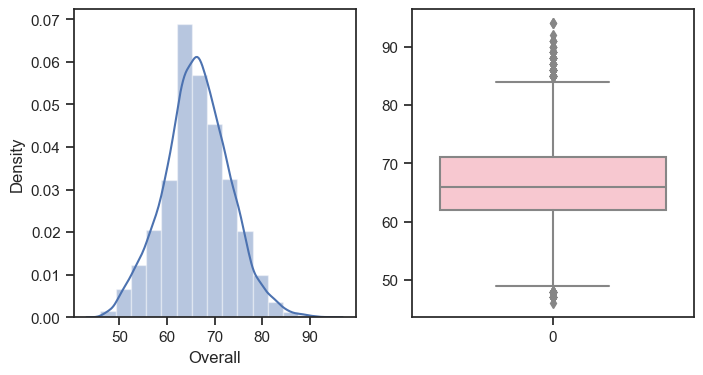

```python
#Exploratory Data Analysis
#-------------------------
#10. Plot the distribution of Overall rating for all the players and write your findings.
Fig, ax = plt.subplots(1, 2, figsize=(8,4))
sns.distplot(Fifa_Df['Overall'],bins=15,ax=ax[0])
sns.boxplot(Fifa_Df['Overall'],ax=ax[1],color='pink')
plt.show()
```

Ploting the distribution of Overall rating for all the players

11. Retrieve the names of top20 players based on the Overall rating.

```python
#Exploratory Data Analysis
#-------------------------
#11. Retrieve the names of top20 players based on the Overall rating.
Fifa_Overall_top20=Fifa_Df.copy()
Fifa_Overall_top20=Fifa_Overall_top20.sort_values(by='Overall',ascending=False)
print(Fifa_Overall_top20[['Name','Overall']].head(20))
```

```
                 Name  Overall
0            L. Messi       94
1   Cristiano Ronaldo       94
2           Neymar Jr       92
3              De Gea       91
4        K. De Bruyne       91
5           E. Hazard       91
6           L. Modrić       91
7           L. Suárez       91
8        Sergio Ramos       91
12           D. Godín       90
13        David Silva       90
9            J. Oblak       90
11           T. Kroos       90
10     R. Lewandowski       90
20    Sergio Busquets       89
24       G. Chiellini       89
23          S. Agüero       89
22           M. Neuer       89
21          E. Cavani       89
16            H. Kane       89
```

12. Generate a dataframe which should include all the information of the Top 20 players based on the Overall rating

```python
#Exploratory Data Analysis
#-------------------------
# 12. Generate a dataframe which should include all the information of the Top 20 players based on the Overall rating.
Fifa_Overall_top20=Fifa_Df.copy()
Fifa_Overall_top20=Fifa_Overall_top20.sort_values(by='Overall',ascending=False)
Fifa_Overall_top20.head(20)
```

|  | ID | Name | Age | Nationality | Overall | Potential | Club | Value | Wage | Preferred Foot | International Reputation | Weak Foot | Skill Moves | Work Rate | Body Type | Position | Jersey Number | Joined | Contract Valid Until | Height | Weight | Crossing | Finishing | HeadingAccuracy | ShortPassing | Volleys | Dribbling | Curve | FKAccuracy | … |
| --- | --- | --- | --- | --- | --- | --- | --- | --- | --- | --- | --- | --- | --- | --- | --- | --- | --- | --- | --- | --- | --- | --- | --- | --- | --- | --- | --- | --- | --- | --- |
| 0 | 158023 | L. Messi | 31 | Argentina | 94 | 94 | FC Barcelona | 110500000.0 | 565000.0 | Left | 5.0 | 4.0 | 4.0 | Medium/ Medium | Messi | RF | 10.0 | 2004 | 2021-12-31 | 5.70 | 159.0 | 84.0 | 95.0 | 70.0 | 90.0 | 86.0 | 97.0 | 93.0 | 94.0 | … |
| 1 | 20801 | Cristiano Ronaldo | 33 | Portugal | 94 | 94 | Juventus | 77000000.0 | 405000.0 | Right | 5.0 | 4.0 | 5.0 | High/ Low | C. Ronaldo | ST | 7.0 | 2018 | 2022-12-31 | 6.20 | 183.0 | 84.0 | 94.0 | 89.0 | 81.0 | 87.0 | 88.0 | 81.0 | 76.0 | … |
| 2 | 190871 | Neymar Jr | 26 | Brazil | 92 | 93 | Paris Saint-Germain | 118500000.0 | 290000.0 | Right | 5.0 | 5.0 | 5.0 | High/ Medium | Neymar | LW | 10.0 | 2017 | 2022-12-31 | 5.90 | 150.0 | 79.0 | 87.0 | 62.0 | 84.0 | 84.0 | 96.0 | 88.0 | 87.0 | … |
| 3 | 193080 | De Gea | 27 | Spain | 91 | 93 | Manchester United | 72000000.0 | 260000.0 | Right | 4.0 | 3.0 | 1.0 | Medium/ Medium | Lean | GK | 1.0 | 2011 | 2020-12-31 | 6.40 | 168.0 | 17.0 | 13.0 | 21.0 | 50.0 | 13.0 | 18.0 | 21.0 | 19.0 | … |
| 4 | 192985 | K. De Bruyne | 27 | Belgium | 91 | 92 | Manchester City | 102000000.0 | 355000.0 | Right | 4.0 | 5.0 | 4.0 | High/ High | Normal | RCM | 7.0 | 2015 | 2023-12-31 | 5.11 | 154.0 | 93.0 | 82.0 | 55.0 | 92.0 | 82.0 | 86.0 | 85.0 | 83.0 | … |
| 5 | 183277 | E. Hazard | 27 | Belgium | 91 | 91 | Chelsea | 93000000.0 | 340000.0 | Right | 4.0 | 4.0 | 4.0 | High/ Medium | Normal | LF | 10.0 | 2012 | 2020-12-31 | 5.80 | 163.0 | 81.0 | 84.0 | 61.0 | 89.0 | 80.0 | 95.0 | 83.0 | 79.0 | … |
| 6 | 177003 | L. Modrić | 32 | Croatia | 91 | 91 | Real Madrid | 67000000.0 | 420000.0 | Right | 4.0 | 4.0 | 4.0 | High/ High | Lean | RCM | 10.0 | 2012 | 2020-12-31 | 5.80 | 146.0 | 86.0 | 72.0 | 55.0 | 93.0 | 76.0 | 90.0 | 85.0 | 78.0 | … |
| 7 | 176580 | L. Suárez | 31 | Uruguay | 91 | 91 | FC Barcelona | 80000000.0 | 455000.0 | Right | 5.0 | 4.0 | 3.0 | High/ Medium | Normal | RS | 9.0 | 2014 | 2021-12-31 | 6.00 | 190.0 | 77.0 | 93.0 | 77.0 | 82.0 | 88.0 | 87.0 | 86.0 | 84.0 | … |
| 8 | 155862 | Sergio Ramos | 32 | Spain | 91 | 91 | Real Madrid | 51000000.0 | 380000.0 | Right | 4.0 | 3.0 | 3.0 | High/ Medium | Normal | RCB | 15.0 | 2005 | 2020-12-31 | 6.00 | 181.0 | 66.0 | 60.0 | 91.0 | 78.0 | 66.0 | 63.0 | 74.0 | 72.0 | … |
| 12 | 182493 | D. Godín | 32 | Uruguay | 90 | 90 | Atlético Madrid | 44000000.0 | 125000.0 | Right | 3.0 | 3.0 | 2.0 | Medium/ High | Lean | CB | 10.0 | 2010 | 2019-12-31 | 6.20 | 172.0 | 55.0 | 42.0 | 92.0 | 79.0 | 47.0 | 53.0 | 49.0 | 51.0 | … |
| 13 | 168542 | David Silva | 32 | Spain | 90 | 90 | Manchester City | 60000000.0 | 285000.0 | Left | 4.0 | 2.0 | 4.0 | High/ Medium | Normal | LCM | 21.0 | 2010 | 2020-12-31 | 5.80 | 148.0 | 84.0 | 76.0 | 54.0 | 93.0 | 82.0 | 89.0 | 82.0 | 77.0 | … |
| 9 | 200389 | J. Oblak | 25 | Slovenia | 90 | 93 | Atlético Madrid | 68000000.0 | 94000.0 | Right | 3.0 | 3.0 | 1.0 | Medium/ Medium | Normal | GK | 1.0 | 2014 | 2021-12-31 | 6.20 | 192.0 | 13.0 | 11.0 | 15.0 | 29.0 | 13.0 | 12.0 | 13.0 | 14.0 | … |
| 11 | 182521 | T. Kroos | 28 | Germany | 90 | 90 | Real Madrid | 76500000.0 | 355000.0 | Right | 4.0 | 5.0 | 3.0 | Medium/ Medium | Normal | LCM | 8.0 | 2014 | 2022-12-31 | 6.00 | 168.0 | 88.0 | 76.0 | 54.0 | 92.0 | 82.0 | 81.0 | 86.0 | 84.0 | … |
| 10 | 188545 | R. Lewandowski | 29 | Poland | 90 | 90 | FC Bayern München | 77000000.0 | 205000.0 | Right | 4.0 | 4.0 | 4.0 | High/ Medium | Normal | ST | 9.0 | 2014 | 2021-12-31 | 6.00 | 176.0 | 62.0 | 91.0 | 85.0 | 83.0 | 89.0 | 85.0 | 77.0 | 86.0 | … |
| 20 | 189511 | Sergio Busquets | 29 | Spain | 89 | 89 | FC Barcelona | 51500000.0 | 315000.0 | Right | 4.0 | 3.0 | 3.0 | Medium/ Medium | Lean | CDM | 5.0 | 2008 | 2023-12-31 | 6.20 | 168.0 | 62.0 | 67.0 | 68.0 | 89.0 | 44.0 | 80.0 | 66.0 | 68.0 | … |
| 24 | 138956 | G. Chiellini | 33 | Italy | 89 | 89 | Juventus | 27000000.0 | 215000.0 | Left | 4.0 | 3.0 | 2.0 | Medium/ High | Normal | LCB | 3.0 | 2005 | 2020-12-31 | 6.20 | 187.0 | 58.0 | 33.0 | 83.0 | 59.0 | 45.0 | 58.0 | 60.0 | 31.0 | … |
| 23 | 153079 | S. Agüero | 30 | Argentina | 89 | 89 | Manchester City | 64500000.0 | 300000.0 | Right | 4.0 | 4.0 | 4.0 | High/ Medium | Stocky | ST | 10.0 | 2011 | 2021-12-31 | 5.80 | 154.0 | 70.0 | 93.0 | 77.0 | 81.0 | 85.0 | 89.0 | 82.0 | 73.0 | … |
| 22 | 167495 | M. Neuer | 32 | Germany | 89 | 89 | FC Bayern München | 38000000.0 | 130000.0 | Right | 5.0 | 4.0 | 1.0 | Medium/ Medium | Normal | GK | 1.0 | 2011 | 2021-12-31 | 6.40 | 203.0 | 15.0 | 13.0 | 25.0 | 55.0 | 11.0 | 30.0 | 14.0 | 11.0 | … |
| 21 | 179813 | E. Cavani | 31 | Uruguay | 89 | 89 | Paris Saint-Germain | 60000000.0 | 200000.0 | Right | 4.0 | 4.0 | 3.0 | High/ High | Lean | LS | 21.0 | 2013 | 2020-12-31 | 6.10 | 170.0 | 70.0 | 89.0 | 89.0 | 78.0 | 90.0 | 80.0 | 77.0 | 76.0 | … |
| 16 | 202126 | H. Kane | 24 | England | 89 | 91 | Tottenham Hotspur | 83500000.0 | 205000.0 | Right | 3.0 | 4.0 | 3.0 | High/ High | Normal | ST | 9.0 | 2010 | 2024-12-31 | 6.20 | 196.0 | 75.0 | 94.0 | 85.0 | 80.0 | 84.0 | 80.0 | 78.0 | 68.0 | … |

13. What is the average "Age" and "Wage" of these top 20 players? (use the data frame created in the question 11)

```python
#Exploratory Data Analysis
#-------------------------
#13. What is the average "Age" and "Wage" of these top 20 players?
# Fifa_Overall_top20[['Age','Wage']].head(20)
Avg_age = round(Fifa_Overall_top20['Age'].mean())
Avg_wage = round(Fifa_Overall_top20['Wage'].mean())

print("Average Age : ",Avg_age,"yrs")
print("Average Wage : €",Avg_wage)
```

```
Average Age :  25 yrs
Average Wage : € 9731
```

14. Among the top 20 players based on the Overall rating, which player has the highest wage?

Display the name of the player with his wage.

```python
#Exploratory Data Analysis
#-------------------------
#14. Among the top 20 players based on the Overall rating,
# which player has the highest wage? Display the name of the player with his wage.

Fifa_Overall_top20.sort_values(by=['Wage','Overall'],axis=0,ascending=[False,False],inplace=False,kind='quicksort', na_position='first', ignore_index=True, key=None)
print(Fifa_Overall_top20[['Name','Wage']].head(1))
```

```
       Name      Wage
0  L. Messi  565000.0
```

15.Generate a dataframe which should include the "Player name", "ClubName", "Wage", and 'Overall rating'.

- i) find the average Overall rating for each club.
- ii) Display the average overall rating of Top10 Clubs using a plot

```python
#Exploratory Data Analysis
#-------------------------
#15.Generate a dataframe which should include the "Player name", "ClubName", "Wage", and 'Overall rating'.
Fifa_Df_colm=Fifa_Df[['Name','Club','Overall','Wage']]
Fifa_Df_colm.head()
```

|  | Name | Club | Overall | Wage |
| --- | --- | --- | --- | --- |
| 0 | L. Messi | FC Barcelona | 94 | 565000.0 |
| 1 | Cristiano Ronaldo | Juventus | 94 | 405000.0 |
| 2 | Neymar Jr | Paris Saint-Germain | 92 | 290000.0 |
| 3 | De Gea | Manchester United | 91 | 260000.0 |
| 4 | K. De Bruyne | Manchester City | 91 | 355000.0 |

```python
#Exploratory Data Analysis
#-------------------------
#15. Generate a dataframe which should include the "Player name", "Club Name", "Wage", and 'Overall rating'.
# - i) find the average Overall rating for each club.
Fifa_Df_colm.groupby('Club')['Overall'].mean()
```

```
Club
 SSV Jahn Regensburg     65.586207
1. FC Heidenheim 1846    65.750000
1. FC Kaiserslautern     63.384615
1. FC Köln               70.785714
1. FC Magdeburg          65.615385
                           ...
Zagłębie Sosnowiec       60.760000
Çaykur Rizespor          66.900000
Örebro SK                60.481481
Östersunds FK            63.545455
Śląsk Wrocław            62.200000
Name: Overall, Length: 651, dtype: float64
```

```
                 Name                 Club  Overall      Wage  Club Overall
0            L. Messi         FC Barcelona       94  565000.0           1.5
1   Cristiano Ronaldo             Juventus       94  405000.0           1.5
2           Neymar Jr  Paris Saint-Germain       92  290000.0           3.0
3              De Gea    Manchester United       91  260000.0           6.5
4        K. De Bruyne      Manchester City       91  355000.0           6.5
5           E. Hazard              Chelsea       91  340000.0           6.5
6           L. Modrić          Real Madrid       91  420000.0           6.5
7           L. Suárez         FC Barcelona       91  455000.0           6.5
8        Sergio Ramos          Real Madrid       91  380000.0           6.5
13        David Silva      Manchester City       90  285000.0          12.0
```

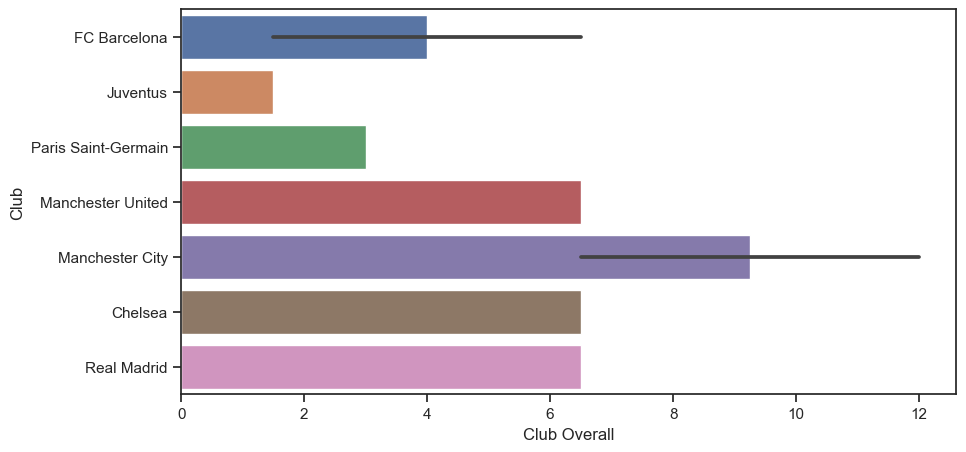

```python
#Exploratory Data Analysis
#-------------------------
#15. Generate a dataframe which should include the "Player name", "Club Name", "Wage", and 'Overall rating'.
#Display average overall rating - ii) Display the average overall rating of Top10 Clubs using a plot

Fifa_DF_colm=Fifa_Df.copy()
Fifa_DF_colm['Club Overall']=Fifa_DF_colm['Overall'].rank(method='average',ascending=False)
Fifa_DF_top10_club=Fifa_DF_colm.sort_values(['Club Overall'],ascending=True).head(10)
plt.figure(figsize=(10,5))
sns.barplot(y='Club', x='Club Overall', data= Fifa_DF_top10_club)

print(Fifa_DF_top10_club[['Name','Club','Overall','Wage','Club Overall']].head(10))
Fifa_DF_top10_club
plt.show()
```

16. What is the relationship between age and individual potential of the

player? Visualize the relationship with appropriate plot and Comment on the same

```python
#Exploratory Data Analysis
#-------------------------
#16 What is the relationship between age and individual potential of the player?
#Visualize the relationship with appropriate plot and Comment on the same
Fifa_Df_Age_Pot_cor = Fifa_Df['Age'].corr(Fifa_Df['Potential'])
print("Correlation between Age and Potential is ", round(Fifa_Df_Age_Pot_cor,2))
```

```
Correlation between Age and Potential is  -0.25
```

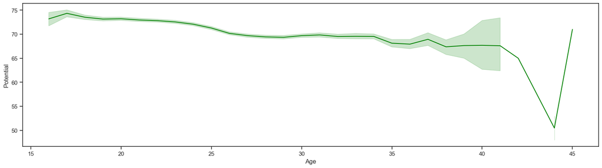

```python
#Exploratory Data Analysis
#-------------------------
# Visualize the relationship with appropriate plot and Comment on the same
plt.figure(figsize=(20,5))
sns.lineplot(x= 'Age', y= 'Potential', data = Fifa_Df, color='green')
plt.show()
```

```python
#Exploratory Data Analysis
#-------------------------
#17. Which features directly contribute to the wages of the players? Support your answer with a plot and a metric. (2 points) (hint: use potential, Overall, value, international reputation, and Release Clause)

Fifa_Df_wageRel=Fifa_Df[['Potential','Overall','Value','International Reputation','Release Clause','Wage']]
Fifa_Df_wageRel.corr()
```

|  | Potential | Overall | Value | International Reputation | Release Clause | Wage |
| --- | --- | --- | --- | --- | --- | --- |
| Potential | 1.000000 | 0.660939 | 0.576218 | 0.372993 | 0.547668 | 0.486413 |
| Overall | 0.660939 | 1.000000 | 0.627085 | 0.499491 | 0.589200 | 0.571926 |
| Value | 0.576218 | 0.627085 | 1.000000 | 0.653176 | 0.967255 | 0.858442 |
| International Reputation | 0.372993 | 0.499491 | 0.653176 | 1.000000 | 0.618094 | 0.668635 |
| Release Clause | 0.547668 | 0.589200 | 0.967255 | 0.618094 | 1.000000 | 0.820162 |
| Wage | 0.486413 | 0.571926 | 0.858442 | 0.668635 | 0.820162 | 1.000000 |

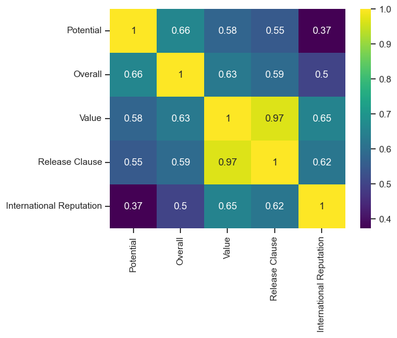

```python
#Exploratory Data Analysis
#-------------------------
#17. Support your answer with a plot and a metric. (2 points) (hint: use potential, Overall, value, international reputation, and Release Clause)

sns.heatmap(Fifa_Df_wageRel[['Potential','Overall','Value','Release Clause','International Reputation']].corr(),annot=True,cmap='viridis')
```

Features directly contribute to the wages of the players Value and Relase Clause are directily prepostional to one another.

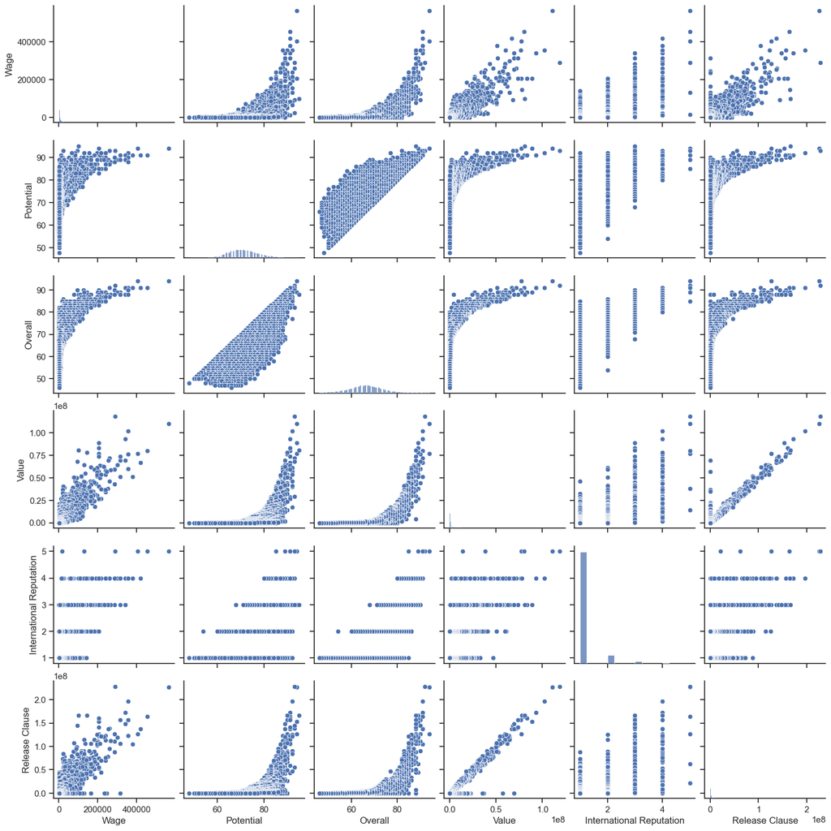

```python
#Exploratory Data Analysis
#-------------------------
# Support your answer with a plot and a metric.
sns.pairplot(Fifa_Df_wageRel[['Wage', 'Potential', 'Overall', 'Value', 'International Reputation', 'Release Clause']])
plt.show()
```

18. Find the position in the pitch where the maximum number of players play

and the position where the minimum number of players play? Display it using a plot.

```python
#Exploratory Data Analysis
#-------------------------
#18. Find the position in the pitch where the maximum number of players play and the position where the minimum number of players play?
Df_pos=Fifa_Df.groupby(['Position'])['Position'].count().reset_index(name='Count').sort_values(by=('Count'),ascending=False)
print("Maximum players paying at Position :"+Df_pos['Position'][Df_pos['Count']==Df_pos['Count'].max()].iloc[0])
print("Minimum players paying at Position :"+ Df_pos['Position'][Df_pos['Count']==Df_pos['Count'].min()].iloc[0])
```

```
Maximum players paying at Position :ST
Minimum players paying at Position :LF
```

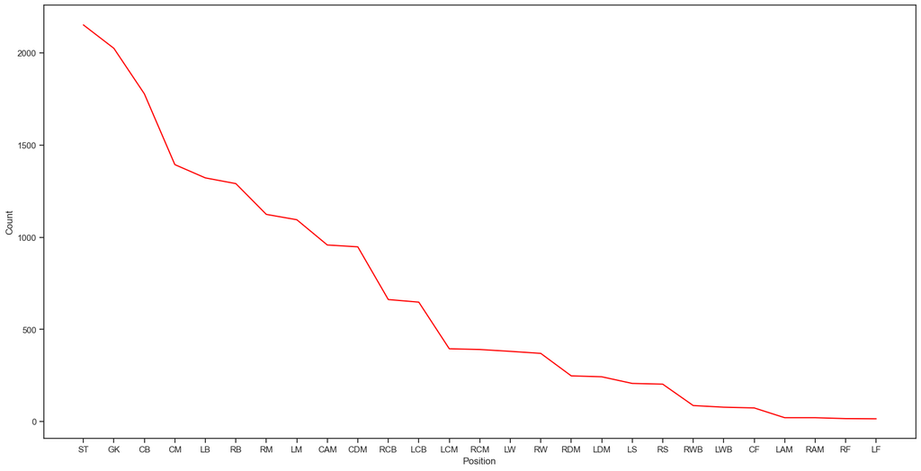

```python
#18.Display it using a plot.
plt.figure(figsize=(20,10))
sns.lineplot(x= 'Position', y= 'Count', data = Df_pos, color='red')
plt.show()
```

Ploting position and number of player

19.How many players are from the club 'Juventus' and the wage is greater than 200K? Display all the information of such players

```python
#Exploratory Data Analysis
#-------------------------
#19. How many players are from the club 'Juventus' and the wage is greater than 200K? Display all the information of such players.
Fifa_Juve=np.where((Fifa_Df['Club']=='Juventus') & (Fifa_Df['Wage']>200000))
Fifa_juve_filter=Fifa_Df.loc[Fifa_Juve]
print(str(Fifa_juve_filter['Club'].count())+" Players in Juventus Club with wages greater than 200k")
```

```
3 Players in Juventus Club with wages greater than 200k
```

```python
#Exploratory Data Analysis
#-------------------------
##19. How many players are from the club 'Juventus' and the wage is greater than 200K? Display all the information of such players.
#3 Players in Juventus Club with wages greater than 200k
Fifa_juve_filter.head()
```

|  | ID | Name | Age | Nationality | Overall | Potential | Club | Value | Wage | Preferred Foot | International Reputation | Weak Foot | Skill Moves | Work Rate | Body Type | Position | Jersey Number | Joined | Contract Valid Until | Height | Weight | Crossing | Finishing | HeadingAccuracy | ShortPassing | Volleys | Dribbling | Curve | FKAccuracy | … |
| --- | --- | --- | --- | --- | --- | --- | --- | --- | --- | --- | --- | --- | --- | --- | --- | --- | --- | --- | --- | --- | --- | --- | --- | --- | --- | --- | --- | --- | --- | --- |
| 1 | 20801 | Cristiano Ronaldo | 33 | Portugal | 94 | 94 | Juventus | 77000000.0 | 405000.0 | Right | 5.0 | 4.0 | 5.0 | High/ Low | C. Ronaldo | ST | 7.0 | 2018 | 2022-12-31 | 6.2 | 183.0 | 84.0 | 94.0 | 89.0 | 81.0 | 87.0 | 88.0 | 81.0 | 76.0 | … |
| 15 | 211110 | P. Dybala | 24 | Argentina | 89 | 94 | Juventus | 89000000.0 | 205000.0 | Left | 3.0 | 3.0 | 4.0 | High/ Medium | Normal | LF | 21.0 | 2015 | 2022-12-31 | 5.1 | 165.0 | 82.0 | 84.0 | 68.0 | 87.0 | 88.0 | 92.0 | 88.0 | 88.0 | … |
| 24 | 138956 | G. Chiellini | 33 | Italy | 89 | 89 | Juventus | 27000000.0 | 215000.0 | Left | 4.0 | 3.0 | 2.0 | Medium/ High | Normal | LCB | 3.0 | 2005 | 2020-12-31 | 6.2 | 187.0 | 58.0 | 33.0 | 83.0 | 59.0 | 45.0 | 58.0 | 60.0 | 31.0 | … |

20. Generate a data frame containing top 5 players by Overall rating for

each unique position.

```python
#Exploratory Data Analysis
#-------------------------
#Generate a data frame containing top 5 players by Overall rating for each unique position.
df_top5_unique_pos = Fifa_Df.groupby(by = ['Position']).apply(lambda x: x.sort_values('Overall', ascending = False).head(5))
display(df_top5_unique_pos)
```

| Position |  | ID | Name | Age | Nationality | Overall | Potential | Club | Value | Wage | Preferred Foot | International Reputation | Weak Foot | Skill Moves | Work Rate | Body Type | Position | Jersey Number | Joined | Contract Valid Until | Height | Weight | Crossing | Finishing | HeadingAccuracy | ShortPassing | Volleys | Dribbling | Curve | … |
| --- | --- | --- | --- | --- | --- | --- | --- | --- | --- | --- | --- | --- | --- | --- | --- | --- | --- | --- | --- | --- | --- | --- | --- | --- | --- | --- | --- | --- | --- | --- |
| CAM | 17 | 194765 | A. Griezmann | 27 | France | 89 | 90 | Atlético Madrid | 78000000.0 | 145000.0 | Left | 4.0 | 3.0 | 4.0 | High/ High | Lean | CAM | 7.0 | 2014 | 2023-12-31 | 5.90 | 161.0 | 82.0 | 90.0 | 84.0 | 83.0 | 87.0 | 88.0 | 84.0 | … |
|  | 31 | 190460 | C. Eriksen | 26 | Denmark | 88 | 91 | Tottenham Hotspur | 73500000.0 | 205000.0 | Right | 3.0 | 5.0 | 4.0 | High/ Medium | Lean | CAM | 10.0 | 2013 | 2020-12-31 | 5.11 | 168.0 | 88.0 | 80.0 | 52.0 | 91.0 | 77.0 | 84.0 | 86.0 | … |
|  | 61 | 201942 | Roberto Firmino | 26 | Brazil | 86 | 87 | Liverpool | 53000000.0 | 195000.0 | Right | 3.0 | 4.0 | 4.0 | High/ High | Lean | CAM | 9.0 | 2015 | 2023-12-31 | 5.11 | 168.0 | 72.0 | 87.0 | 77.0 | 86.0 | 81.0 | 87.0 | 80.0 | … |
|  | 66 | 189596 | T. Müller | 28 | Germany | 86 | 86 | FC Bayern München | 45000000.0 | 135000.0 | Right | 4.0 | 4.0 | 3.0 | High/ High | Lean | CAM | 13.0 | 2008 | 2021-12-31 | 6.10 | 165.0 | 79.0 | 87.0 | 82.0 | 83.0 | 84.0 | 75.0 | 81.0 | … |
|  | 74 | 176635 | M. Özil | 29 | Germany | 86 | 86 | Arsenal | 43500000.0 | 190000.0 | Left | 4.0 | 2.0 | 4.0 | Medium/ Low | Lean | CAM | 10.0 | 2013 | 2021-12-31 | 5.11 | 168.0 | 83.0 | 73.0 | 54.0 | 89.0 | 80.0 | 84.0 | 84.0 | … |
| ... | ... | ... | ... | ... | ... | ... | ... | ... | ... | ... | ... | ... | ... | ... | ... | ... | ... | ... | ... | ... | ... | ... | ... | ... | ... | ... | ... | ... | ... | … |
| ST | 1 | 20801 | Cristiano Ronaldo | 33 | Portugal | 94 | 94 | Juventus | 77000000.0 | 405000.0 | Right | 5.0 | 4.0 | 5.0 | High/ Low | C. Ronaldo | ST | 7.0 | 2018 | 2022-12-31 | 6.20 | 183.0 | 84.0 | 94.0 | 89.0 | 81.0 | 87.0 | 88.0 | 81.0 | … |
|  | 10 | 188545 | R. Lewandowski | 29 | Poland | 90 | 90 | FC Bayern München | 77000000.0 | 205000.0 | Right | 4.0 | 4.0 | 4.0 | High/ Medium | Normal | ST | 9.0 | 2014 | 2021-12-31 | 6.00 | 176.0 | 62.0 | 91.0 | 85.0 | 83.0 | 89.0 | 85.0 | 77.0 | … |
|  | 16 | 202126 | H. Kane | 24 | England | 89 | 91 | Tottenham Hotspur | 83500000.0 | 205000.0 | Right | 3.0 | 4.0 | 3.0 | High/ High | Normal | ST | 9.0 | 2010 | 2024-12-31 | 6.20 | 196.0 | 75.0 | 94.0 | 85.0 | 80.0 | 84.0 | 80.0 | 78.0 | … |
|  | 23 | 153079 | S. Agüero | 30 | Argentina | 89 | 89 | Manchester City | 64500000.0 | 300000.0 | Right | 4.0 | 4.0 | 4.0 | High/ Medium | Stocky | ST | 10.0 | 2011 | 2021-12-31 | 5.80 | 154.0 | 70.0 | 93.0 | 77.0 | 81.0 | 85.0 | 89.0 | 82.0 | … |
|  | 36 | 173731 | G. Bale | 28 | Wales | 88 | 88 | Real Madrid | 60000000.0 | 355000.0 | Left | 4.0 | 3.0 | 4.0 | High/ Medium | Lean | ST | 11.0 | 2013 | 2022-12-31 | 6.10 | 181.0 | 87.0 | 86.0 | 84.0 | 85.0 | 85.0 | 87.0 | 90.0 | … |

135 rows × 56 columns

21. What is the average wage one can expect to pay for the top 5 players

in every position? (use the data frame created in Q19)

```python
#Exploratory Data Analysis
#-------------------------
#21What is the average wage one can expect to pay for the top 5 players in every position? (use the data frame created in Q19)
avg_wage= df_top5_unique_pos['Wage'].groupby('Position').apply(np.mean)
print(avg_wage)
```

```
Position
CAM    174000.0
CB     139600.0
CDM    217000.0
CF      47400.0
CM     130600.0
GK     192800.0
LAM     81600.0
LB     177200.0
LCB    162000.0
LCM    184400.0
LDM    126600.0
LF     121200.0
LM     164600.0
LS     130200.0
LW     261000.0
LWB     34200.0
RAM     45400.0
RB     155400.0
RCB    231000.0
RCM    240800.0
RDM    105000.0
RF     148000.0
RM     131400.0
RS     132200.0
RW     202000.0
RWB     44200.0
ST     294000.0
Name: Wage, dtype: float64
```